# ECT_Analysis

Faraz Hassan

7/11/2023

## Reading in patient data for neuroimage processing

data.csv <- read.csv(‘/nethome/fhassan3/IPERSR-MRISessionsAndName_DATA_2023-05-31_1058.csv’)

## Copying T1 and T2 images from supervisor’s to my directory and adding timepoint variable for running longitudinal analysis using freesurfer

# T1 image copy

for (x in 1:nrow(data.csv)){ i = data.csv[x,7] j = data.csv[x,9] file_from <- paste0(‘/data/BIDS/sub-’,j,‘/ses-’,i,‘/anat’,‘/sub-’,j,‘_ses-’,i,‘_run-01_T1w.nii.gz’)

k = sprintf(“%02d”, data.csv[x,4]) file_to <- paste0(‘/nethome/fhassan3/LongFreesurfer/sub-’,j,‘_ses-’,i,‘_tp-’, k,‘_T1w.nii.gz’) print(file_to) file.copy(file_from, file_to) }

# T2 image copy

for (x in 1:nrow(data.csv)){ i = data.csv[x,7] j = data.csv[x,9] file_from <- paste0(‘/data/BIDS/sub-’,j,‘/ses-’,i,‘/anat’,‘/sub-’,j,‘_ses-’,i,‘_run-01_T2w.nii.gz’)

k = sprintf(“%02d”, data.csv[x,4]) file_to <- paste0(‘/nethome/fhassan3/LongFreesurfer/sub-’,j,‘_ses-’,i,‘_tp-’, k,‘_T2w.nii.gz’) print(file_to) file.copy(file_from, file_to) }

## Generating new text file that contains bash code for reconstruction of T1 and T2 images of 4 patients using freesurfer through docker

# recon of T1 and T2 images using docker

file_path = ‘/nethome/fhassan3/recon.txt’ for (x in 1:nrow(data.csv)){ i = data.csv[x,7] j = data.csv[x,9] k = sprintf(“%02d”, data.csv[x,4]) new_line <- paste0(‘echo -n “docker run -i –rm -v /nethome/fhassan3/LongFreesurfer/:/data -v /nethome/fhassan3/LongFreesurfer/OUTPUT/:/usr/local/freesurfer/subjects -v /usr/local/opt/freesurfer7.1/.license:/usr/local/freesurfer/.license freesurfer/freesurfer:7.1.1 /bin/bash -c ‘,“’”,’recon-all -s’,j,‘_’,k,’ -i /data/sub-‘,j,’_ses-‘,i,’_tp-‘,k,’_T1w.nii.gz -T2 /data/sub-‘,j,’_ses-‘,i,’_tp-‘,k,’*T2w.nii.gz -T2pial -all’,“‘“,’”‘,’| qsub -o /nethome/amiklos/QSUB_OUTPUT/test_0’,i,’ -e /nethome/amiklos/QSUB_OUTPUT/teste*’,i) write(new_line, file_path, append=TRUE) }

## Generating text file for base recon for running longitudinal freesurfer analysis

s <- unique(data.csv$grid) v <- as.list(s) base_path = ‘/nethome/fhassan3/recon_base.txt’ for(x in v) { if (x < 14160) { tp <- ’’ for (y in 1:10){ k = sprintf(“%02d”, y) new_line1 <- paste0(’ -tp /usr/local/freesurfer/subjects/‘,x,’*‘, k) tp <- paste0(tp, new_line1) } new_line2 <- paste0(’echo -n “docker run -i –rm -v /nethome/fhassan3/LongFreesurfer/:/data -v /nethome/fhassan3/LongFreesurfer/OUTPUT/:/usr/local/freesurfer/subjects -v /usr/local/opt/freesurfer7.1/.license:/usr/local/freesurfer/.license freesurfer/freesurfer:7.1.1 /bin/bash -c ‘,“‘“,‘recon-all -base’, x, ‘base’,tp,’ -all’,”’”,’”’,‘| qsub -o /nethome/amiklos/QSUB_OUTPUT/test_0’,x,’ -e /nethome/amiklos/QSUB_OUTPUT/teste*’,x) write(new_line2, base_path, append=TRUE) } else { tp <- ’’ for (y in 1:5){ k = sprintf(“%02d”, y) new_line3 <- paste0(’ -tp /usr/local/freesurfer/subjects/‘,x,’‘, k) tp <- paste0(tp, new_line3) } new_line4 <- paste0(’echo -n “docker run -i –rm -v /nethome/fhassan3/LongFreesurfer/:/data -v /nethome/fhassan3/LongFreesurfer/OUTPUT/:/usr/local/freesurfer/subjects -v /usr/local/opt/freesurfer7.1/.license:/usr/local/freesurfer/.license freesurfer/freesurfer:7.1.1 /bin/bash -c ‘,“’”,’recon-all -base’, x, ‘*base’,tp,’ -all’,“‘“,’”’,’| qsub -o /nethome/amiklos/QSUB_OUTPUT/test_0’,x,’ -e /nethome/amiklos/QSUB_OUTPUT/teste*’,x) write(new_line4, base_path, append=TRUE) } }

## Generating text file for long recon for running longitudinal freesurfer analysis (final step)

long_path = ‘/nethome/fhassan3/recon_long.txt’ for (x in 1:nrow(data.csv)){ i = data.csv[x,9] j = sprintf(“%02d”, data.csv[x,4]) new_line <- paste0(‘echo -n “docker run -i –rm -v /nethome/fhassan3/LongFreesurfer/:/data -v /nethome/fhassan3/LongFreesurfer/OUTPUT/:/usr/local/freesurfer/subjects -v /usr/local/opt/freesurfer7.1/.license:/usr/local/freesurfer/.license freesurfer/freesurfer:7.1.1 /bin/bash -c ‘,“’”,’recon-all -long /usr/local/freesurfer/subjects/’,i,‘*’, j,’ /usr/local/freesurfer/subjects/’, i, ’base -all’,“‘“,’”’,’| qsub -o /nethome/amiklos/QSUB_OUTPUT/test_0’,i,’*’,j,’ -e /nethome/amiklos/QSUB_OUTPUT/teste’,i,‘_’,j) write(new_line, long_path, append=TRUE) }

unique(data.csv$grid) s <- unique(data.csv$grid) v <- as.list(s) for(x in v) { if (x < 14160) { tp <- ’’ for (y in 1:10){ k = sprintf(“%02d”, y) new_line1 <- paste0(’ -tp /usr/local/freesurfer/subjects/‘,x,’*‘, k) tp <- paste0(tp, new_line1) } new_line2 <- paste0(’echo -n “docker run -i –rm -v /nethome/fhassan3/LongFreesurfer/:/data -v /nethome/fhassan3/LongFreesurfer/OUTPUT/:/usr/local/freesurfer/subjects -v /usr/local/opt/freesurfer7.1/.license:/usr/local/freesurfer/.license freesurfer/freesurfer:7.1.1 /bin/bash -c ‘,“‘“,‘recon-all -base’, x, ‘base’,tp,’ -all’,”’”,’”’,‘| qsub -o /nethome/amiklos/QSUB_OUTPUT/test_0’,x,’ -e /nethome/amiklos/QSUB_OUTPUT/teste*’,x) write(new_line2, base_path, append=TRUE) } else { tp <- ’’ for (y in 1:5){ k = sprintf(“%02d”, y) new_line3 <- paste0(’ -tp /usr/local/freesurfer/subjects/‘,x,’‘, k) tp <- paste0(tp, new_line3) } new_line4 <- paste0(’echo -n “docker run -i –rm -v /nethome/fhassan3/LongFreesurfer/:/data -v /nethome/fhassan3/LongFreesurfer/OUTPUT/:/usr/local/freesurfer/subjects -v /usr/local/opt/freesurfer7.1/.license:/usr/local/freesurfer/.license freesurfer/freesurfer:7.1.1 /bin/bash -c ‘,“’”,’recon-all -base’, x, ‘*base’,tp,’ -all’,“‘“,’”’,’| qsub -o /nethome/amiklos/QSUB_OUTPUT/test_0’,x,’ -e /nethome/amiklos/QSUB_OUTPUT/teste*’,x) write(new_line4, base_path, append=TRUE) }

## Packages used in analysis

```r
library("dplyr")
```

```r
library(ggplot2)
library(tibble)
library(tidyverse)
```

## Loading aseg(fvoldf) and aparc(aparc_vol) data from longitudinal analysis performed on 4 patients across their mris

```r
for (grid in c('13900', '13903', '14071', '14160')){
  filename = paste0("aseg_stats_", grid,".txt")
  voldf <- read.table(filename, sep = "\t", header = T)
  voldf$time <- 1:dim(voldf)[1]
  voldf$grid <- as.numeric(grid)
  if (grid=='13900')
  {
    fvoldf <- voldf
  }else
  {
    fvoldf <- rbind(fvoldf, voldf)
  }
}
head(fvoldf)
```

```
##             Measure.volume Left.Lateral.Ventricle Left.Inf.Lat.Vent
## 1 13900_01.long.13900_base                25050.0            1003.4
## 2 13900_02.long.13900_base                23211.8             907.1
## 3 13900_03.long.13900_base                23889.3             964.8
## 4 13900_04.long.13900_base                23363.7             923.9
## 5 13900_05.long.13900_base                22363.4             803.4
## 6 13900_06.long.13900_base                22113.2             773.6
##   Left.Cerebellum.White.Matter Left.Cerebellum.Cortex Left.Thalamus
## 1                      11839.7                54444.2        6682.3
## 2                      12029.8                54409.3        6801.2
## 3                      11841.7                53661.4        6783.3
## 4                      11942.8                55634.0        6965.7
## 5                      11692.3                54000.9        6915.6
## 6                      12097.0                55075.8        6959.4
##   Left.Caudate Left.Putamen Left.Pallidum X3rd.Ventricle X4th.Ventricle
```

[output cut: 104 more lines]

```r
for (grid in c('13900', '13903', '14071', '14160')){
    filename = paste0("aparc_stats_",grid,"_LH.txt")
    lvol <- read.table(filename, sep = "\t", header = T)
    lvol$time <- 1:dim(voldf)[1]
    lvol$grid <- as.numeric(grid)
    if (grid=='13900'){
        lvoldf <- lvol
        }
    else{
    lvoldf <- rbind(lvoldf, lvol)
    }
}
for (grid in c('13900', '13903', '14071', '14160')){
  filename = paste0("aparc_stats_",grid,"_RH.txt")
  rvol <- read.table(filename, sep = "\t", header = T)
  rvol$time <- 1:dim(voldf)[1]
  rvol$grid <- as.numeric(grid)
    if (grid=='13900')
    {
      rvoldf <- rvol
      }
  else
        {
          rvoldf <- rbind(rvoldf, rvol)
          }
}
aparc_vol <- cbind(lvoldf, rvoldf)
head(aparc_vol)
```

```
##         lh.aparc.thickness lh_bankssts_thickness
## 1 13900_01.long.13900_base                 2.374
## 2 13900_02.long.13900_base                 2.404
## 3 13900_03.long.13900_base                 2.356
## 4 13900_04.long.13900_base                 2.284
## 5 13900_05.long.13900_base                 2.438
## 6 13900_06.long.13900_base                 2.455
##   lh_caudalanteriorcingulate_thickness lh_caudalmiddlefrontal_thickness
## 1                                2.279                            2.480
## 2                                2.361                            2.474
## 3                                2.334                            2.485
## 4                                2.299                            2.560
## 5                                2.349                            2.563
## 6                                2.316                            2.551
##   lh_cuneus_thickness lh_entorhinal_thickness lh_fusiform_thickness
```

[output cut: 237 more lines]

## Loading patient data without personal information and filtering out the 4 specific patients

```r
iper <- read.csv("IPERSR_DATA_2023-06-21_1423.csv")
iper <- iper %>% filter(record_id %in% c(58,59,61,62))
iper$ect_date <- as.Date(iper$ect_date, format = "%d/%m/%y")
iper$date_mri <- as.Date(iper$date_mri, format = "%d/%m/%y")
```

## Establishing net change response variable for left/right hippocampus(aseg), amygdala(aseg), and insula(aparc) volumes across 4 patients at each mri

```r
fvoldf['NRhip'] <- 0
for (grid in c('13900', '13903', '14071', '14160')){
  ix <- which(fvoldf$grid==grid)
  ix1 <- which((fvoldf$grid==grid) & (fvoldf$time==1))
  fvoldf$NRhip[ix]<-  (fvoldf$Right.Hippocampus[ix]-fvoldf$Right.Hippocampus[ix1])/fvoldf$Right.Hippocampus[ix1]
}
fvoldf['NLhip'] <- 0
for (grid in c('13900', '13903', '14071', '14160')){
  ix <- which(fvoldf$grid==grid)
  ix1 <- which((fvoldf$grid==grid) & (fvoldf$time==1))
  fvoldf$NLhip[ix]<-  (fvoldf$Left.Hippocampus[ix]-fvoldf$Left.Hippocampus[ix1])/fvoldf$Left.Hippocampus[ix1]
}
fvoldf['NRami'] <- 0
for (grid in c('13900', '13903', '14071', '14160'))
{
  ix <- which(fvoldf$grid==grid)
  ix1 <- which((fvoldf$grid==grid) & (fvoldf$time==1))
  fvoldf$NRami[ix] <-  (fvoldf$Right.Amygdala[ix]-fvoldf$Right.Amygdala[ix1])/fvoldf$Right.Amygdala[ix1]
}
fvoldf['NLami'] <- 0
for (grid in c('13900', '13903', '14071', '14160'))
{
  ix <- which(fvoldf$grid==grid)
  ix1 <- which((fvoldf$grid==grid) & (fvoldf$time==1))
  fvoldf$NLami[ix] <-  (fvoldf$Left.Amygdala[ix]-fvoldf$Left.Amygdala[ix1])/fvoldf$Left.Amygdala[ix1]
}

aparc_vol['NRins'] <- 0
for (grid in c('13900', '13903', '14071', '14160')){
   ix <- which(aparc_vol$grid==grid)
   ix1 <- which((aparc_vol$grid==grid) & (aparc_vol$time==1))
   aparc_vol$NRins[ix]<-  (aparc_vol$rh_insula_thickness[ix]-aparc_vol$rh_insula_thickness[ix1])/aparc_vol$rh_insula_thickness[ix1]
}
aparc_vol['NLins'] <- 0
for (grid in c('13900', '13903', '14071', '14160')){
  ix <- which(aparc_vol$grid==grid)
  ix1 <- which((aparc_vol$grid==grid) & (aparc_vol$time==1))
  aparc_vol$NLins[ix]<-  (aparc_vol$lh_insula_thickness[ix]-aparc_vol$lh_insula_thickness[ix1])/aparc_vol$lh_insula_thickness[ix1]
}
```

## Establishing variable ect_level2 (ect dosage) received by patients by calculating product from ect frequency and stimulation duration for every ECT treated on patients

```r
for(x in 1:nrow(iper)){
  iper$ect_level2[x] <- iper$frequency[x] * iper$stim_duration[x]
}

#adding ect dosage if second ect received in same day
for(x in 1:nrow(iper)){
  iper$ect_level3[x] <- (iper$frequency_2[x] * iper$stim_duration_2[x]) + (iper$frequency[x] * iper$stim_duration[x])
}

for(x in 1:nrow(iper)){
  if (is.na(iper$ect_level3[x]) == FALSE) {
    iper$ect_level2[x] <- iper$ect_level3[x]
  }
}
```

## Establishing variable ect_total, based on total ect dosage received by each patient before a particular mri

```r
test_1 <- data.frame(iper$record_id, iper$redcap_event_name, iper$gridnumber, iper$redcap_repeat_instance, iper$frequency, iper$ect_completed_pre_mri, iper$stim_duration, iper$frequency_2, iper$stim_duration_2, iper$ect_level2)

test_1 <- test_1 %>%
  add_column(ect_total = 0)

for (x in 2:nrow(test_1)){
  if (test_1$iper.redcap_event_name[x] == 'ect_arm_1' ){
    test_1$ect_total[x] <- as.numeric(test_1$iper.ect_level2[x])+as.numeric(test_1$ect_total[x-1])
  }
}

ect_1 <- select(filter(test_1, iper.redcap_event_name == 'ect_arm_1' & iper.record_id == 58 ),c(iper.redcap_repeat_instance, ect_total))
ect_2 <- select(filter(test_1, iper.redcap_event_name == 'ect_arm_1' & iper.record_id == 59 ),c(iper.redcap_repeat_instance, ect_total))
ect_3 <- select(filter(test_1, iper.redcap_event_name == 'ect_arm_1' & iper.record_id == 61 ),c(iper.redcap_repeat_instance, ect_total))
ect_4 <- select(filter(test_1, iper.redcap_event_name == 'ect_arm_1' & iper.record_id == 62 ),c(iper.redcap_repeat_instance, ect_total))

test_1$iper.ect_completed_pre_mri[15] <- 13

for (x in 2:nrow(test_1)){
  if (test_1$iper.redcap_event_name[x] == 'mri_arm_1' & test_1$iper.record_id[x] == 58){
    i <- as.numeric(test_1$iper.ect_completed_pre_mri[x])
    if (i == 0) {
      test_1$ect_total[x] <- 0
    }
    else {
      test_1$ect_total[x] <- as.numeric(ect_1$ect_total[i])
    }
  }
  else if (test_1$iper.redcap_event_name[x] == 'mri_arm_1' & test_1$iper.record_id[x] == 59){
    i <- as.numeric(test_1$iper.ect_completed_pre_mri[x])
    if (i == 0) {
      test_1$ect_total[x] <- 0
    }
    else {
      test_1$ect_total[x] <- as.numeric(ect_2$ect_total[i])
    }
  }
  else if (test_1$iper.redcap_event_name[x] == 'mri_arm_1' & test_1$iper.record_id[x] == 61){
    i <- as.numeric(test_1$iper.ect_completed_pre_mri[x])
    if (i == 0) {
      test_1$ect_total[x] <- 0
    }
    else {
      test_1$ect_total[x] <- as.numeric(ect_3$ect_total[i])
    }
  }
  else if (test_1$iper.redcap_event_name[x] == 'mri_arm_1' & test_1$iper.record_id[x] == 62){
    i <- as.numeric(test_1$iper.ect_completed_pre_mri[x])
    if (i == 0) {
      test_1$ect_total[x] <- 0
    }
    else {
      test_1$ect_total[x] <- as.numeric(ect_4$ect_total[i])
    }
  }
}


ect <- select(filter(test_1, iper.redcap_event_name == 'mri_arm_1' ),c(iper.record_id, iper.gridnumber, iper.ect_completed_pre_mri, iper.redcap_repeat_instance, ect_total))
for (x in 1:nrow(ect)){
  if (ect$iper.record_id[x] == 58){
    ect$iper.gridnumber[x] <- 13900
  }
  else if (ect$iper.record_id[x] == 59){
    ect$iper.gridnumber[x] <- 13903
  }
  else if (ect$iper.record_id[x] == 61){
    ect$iper.gridnumber[x] <- 14071
  }
  else if (ect$iper.record_id[x] == 62){
    ect$iper.gridnumber[x] <- 14160
  }
}
```

## Combining ect_total variable to above aseg and aparc data

```r
fvoldf <- cbind(fvoldf, ect$ect_total)
colnames(fvoldf)[which(colnames(fvoldf)=='ect$ect_total')] <- 'ect_total'
fvoldf
```

```
##              Measure.volume Left.Lateral.Ventricle Left.Inf.Lat.Vent
## 1  13900_01.long.13900_base                25050.0            1003.4
## 2  13900_02.long.13900_base                23211.8             907.1
## 3  13900_03.long.13900_base                23889.3             964.8
## 4  13900_04.long.13900_base                23363.7             923.9
## 5  13900_05.long.13900_base                22363.4             803.4
## 6  13900_06.long.13900_base                22113.2             773.6
## 7  13900_07.long.13900_base                21791.6             741.5
## 8  13900_08.long.13900_base                21131.4             688.4
## 9  13900_09.long.13900_base                21669.7             800.2
## 10 13900_10.long.13900_base                22091.2             801.0
## 11 13903_01.long.13903_base                 4902.0             389.5
## 12 13903_02.long.13903_base                 5034.3             432.1
## 13 13903_03.long.13903_base                 4879.7             378.5
## 14 13903_04.long.13903_base                 4655.8             344.0
```

[output cut: 597 more lines]

```r
aparc <- cbind(aparc_vol, ect$ect_total)
colnames(aparc)[which(colnames(aparc)=='ect$ect_total')]<-'ect_total'
aparc
```

```
##          lh.aparc.thickness lh_bankssts_thickness
## 1  13900_01.long.13900_base                 2.374
## 2  13900_02.long.13900_base                 2.404
## 3  13900_03.long.13900_base                 2.356
## 4  13900_04.long.13900_base                 2.284
## 5  13900_05.long.13900_base                 2.438
## 6  13900_06.long.13900_base                 2.455
## 7  13900_07.long.13900_base                 2.432
## 8  13900_08.long.13900_base                 2.455
## 9  13900_09.long.13900_base                 2.435
## 10 13900_10.long.13900_base                 2.401
## 11 13903_01.long.13903_base                 2.507
## 12 13903_02.long.13903_base                 2.579
## 13 13903_03.long.13903_base                 2.547
## 14 13903_04.long.13903_base                 2.609
```

[output cut: 1317 more lines]

## Graphs for volume changes in left/right hippocampus against total ect received by patients before given mri across the 4 different patients

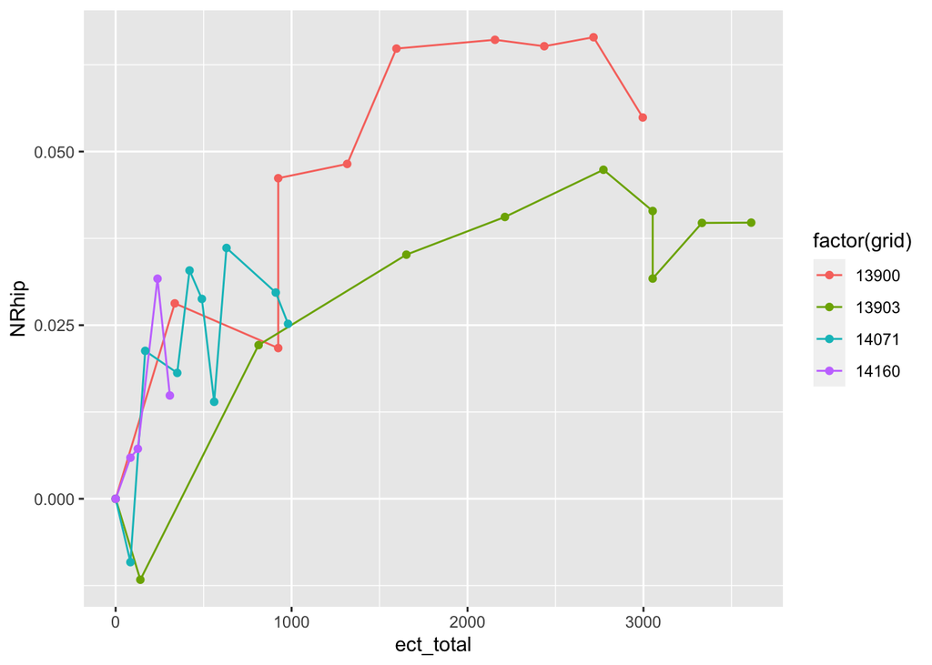

```r
#NRhip over ect levels
ggplot(data=fvoldf, aes(x=ect_total, y=NRhip, colour=factor(grid)))+
  geom_line()+
  geom_point()
```

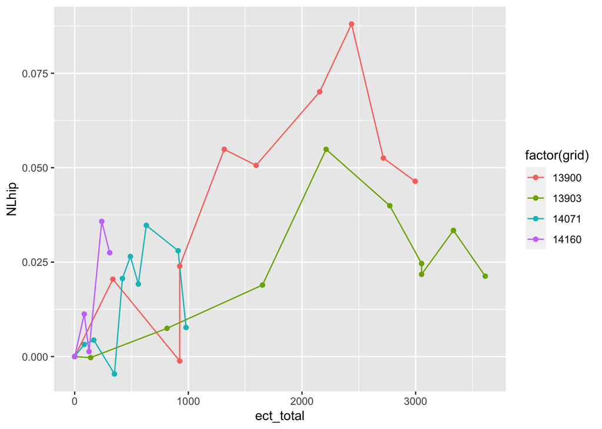

```r
#NLhip over ect levels
ggplot(data=fvoldf, aes(x=ect_total, y=NLhip, colour=factor(grid)))+
  geom_line()+
  geom_point()
```

## Graphs for volume changes in left/right amygdala against total ect received by patients before given mri across the 4 different patients

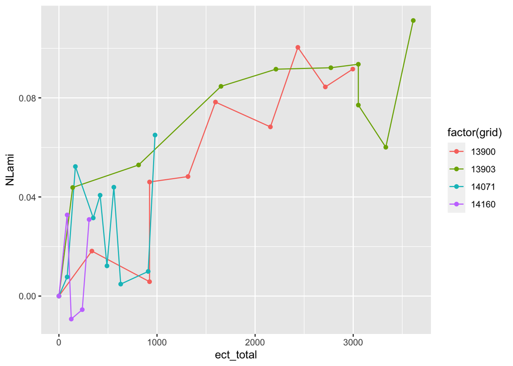

```r
#NLami over ect levels
ggplot(data=fvoldf, aes(x=ect_total, y=NLami, colour=factor(grid)))+
  geom_line()+
  geom_point()
```

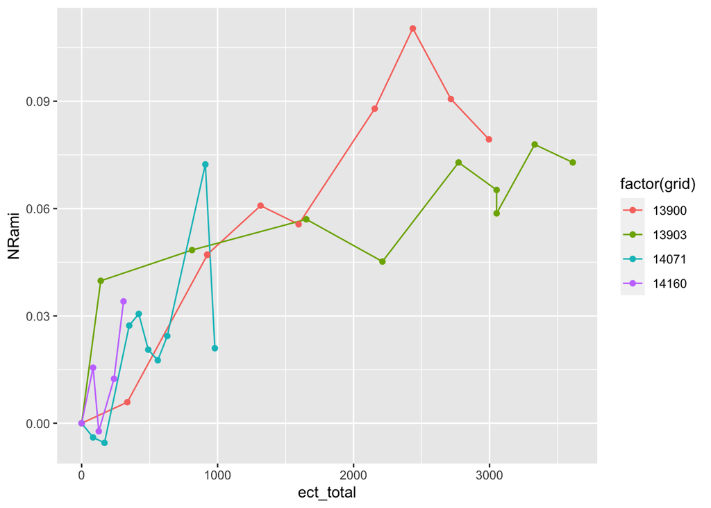

```r
#NRami over ect levels
ggplot(data=fvoldf, aes(x=ect_total, y=NRami, colour=factor(grid)))+
  geom_line()+
  geom_point()
```

## Graphs for thickness changes in left/right insula against total ect received by patients before given mri across the 4 different patients

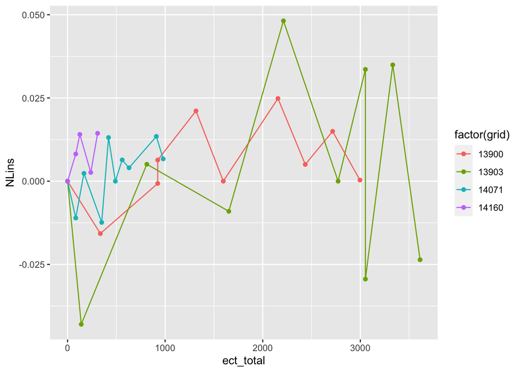

```r
#NLins
ggplot(data=aparc, aes(x=ect_total, y=NLins, colour=factor(grid)))+
  geom_line()+
  geom_point()
```

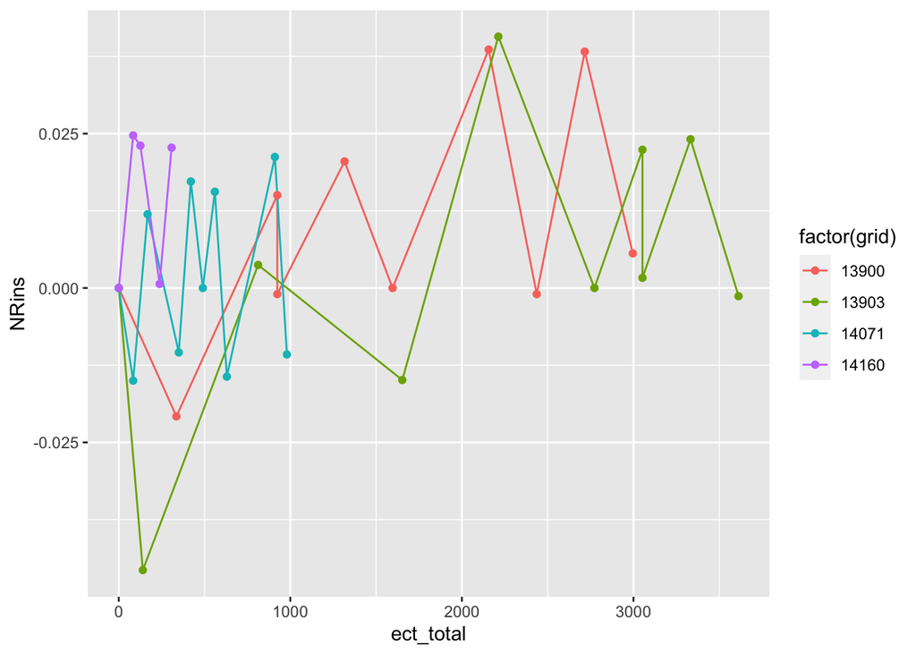

```r
#NRins
ggplot(data=aparc, aes(x=ect_total, y=NRins, colour=factor(grid)))+
  geom_line()+
  geom_point()
```

## Establishing variable last_ect from time allocated differences between mri dates and the ect date of the closest ect received before the mri date; trying to answer the spikes of left and right insula thickness changes over ect_total

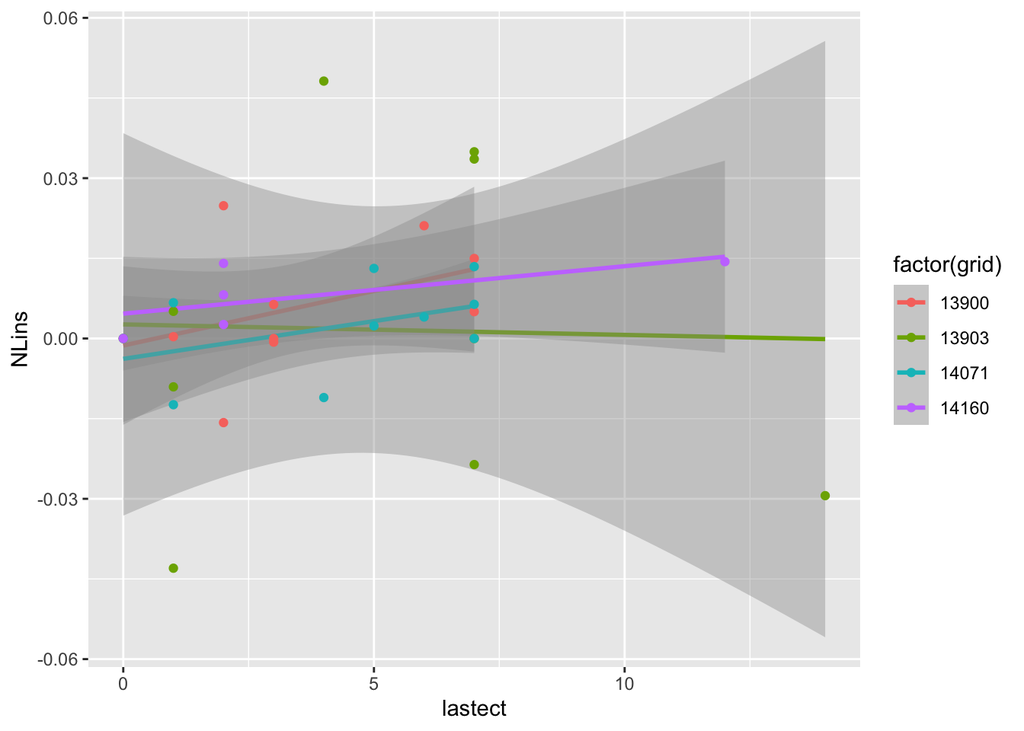

```r
test_2 <- data.frame(iper$record_id, iper$redcap_event_name, iper$gridnumber, iper$redcap_repeat_instance, iper$ect_completed_pre_mri, iper$date_mri, iper$ect_date)
for (x in 1:nrow(test_2)){
  if (test_2$iper.record_id[x] == 58){
    test_2$iper.gridnumber[x] <- 13900
  }
  else if (test_2$iper.record_id[x] == 59){
    test_2$iper.gridnumber[x] <- 13903
  }
  else if (test_2$iper.record_id[x] == 61){
    test_2$iper.gridnumber[x] <- 14071
  }
  else if (test_2$iper.record_id[x] == 62){
    test_2$iper.gridnumber[x] <- 14160
  }
}
test_2$iper.ect_completed_pre_mri[15] <- 13
dates_1 <- select(filter(test_2, iper.redcap_event_name == 'ect_arm_1' & iper.record_id == 58 ),c(iper.redcap_repeat_instance, iper.ect_date))
dates_2 <- select(filter(test_2, iper.redcap_event_name == 'ect_arm_1' & iper.record_id == 59 ),c(iper.redcap_repeat_instance, iper.ect_date))
dates_3 <- select(filter(test_2, iper.redcap_event_name == 'ect_arm_1' & iper.record_id == 61 ),c(iper.redcap_repeat_instance, iper.ect_date))
dates_4 <- select(filter(test_2, iper.redcap_event_name == 'ect_arm_1' & iper.record_id == 62 ),c(iper.redcap_repeat_instance, iper.ect_date))


test_2['last_ect'] <- 0

for (x in 1:nrow(test_2)){
  if (test_2$iper.redcap_event_name[x] == 'mri_arm_1' & test_2$iper.record_id[x] == 58){
    i <- test_2$iper.ect_completed_pre_mri[x]
    if (i==0){
      test_2$last_ect[x] <- as.numeric(0)
    }
    else{
      test_2$last_ect[x] <- as.integer(difftime(test_2$iper.date_mri[x], dates_1$iper.ect_date[i]))
    }
  }
  else if (test_2$iper.redcap_event_name[x] == 'mri_arm_1' & test_2$iper.record_id[x] == 59){
    i <- test_2$iper.ect_completed_pre_mri[x]
    if(i == 0){
      test_2$last_ect[x] <- as.numeric(0)
    }
    else{
      test_2$last_ect[x] <- as.integer(difftime(test_2$iper.date_mri[x], dates_2$iper.ect_date[i]))
    }
  }
  else if (test_2$iper.redcap_event_name[x] == 'mri_arm_1' & test_2$iper.record_id[x] == 61){
    i <- test_2$iper.ect_completed_pre_mri[x]
    if (i==0){
      test_2$last_ect[x] <- as.numeric(0)
    }
    else{
      test_2$last_ect[x] <- as.integer(difftime(test_2$iper.date_mri[x], dates_3$iper.ect_date[i]))
    }
  }
  else if (test_2$iper.redcap_event_name[x] == 'mri_arm_1' & test_2$iper.record_id[x] == 62){
    i <- test_2$iper.ect_completed_pre_mri[x]
    if (i == 0){
      test_2$last_ect[x] <- as.numeric(0)
    }
    else{
      test_2$last_ect[x] <- as.integer(difftime(test_2$iper.date_mri[x], dates_4$iper.ect_date[i]))
    }
  }
  else {
    test_2$last_ect[x] <- NA
  }
}

time_analysis <- select(filter(test_2, iper.redcap_event_name == 'mri_arm_1' ),c(iper.record_id, iper.gridnumber, iper.redcap_repeat_instance, last_ect))

aparc <- cbind(aparc, time_analysis$last_ect)
colnames(aparc)[which(colnames(aparc)=='time_analysis$last_ect')]<-'lastect'

#Testing last ect hypothesis for insula thickness changes
ggplot(data=aparc, aes(x=lastect, y=NLins, colour=factor(grid)))+
  stat_smooth(method='lm')+
  geom_point()
```

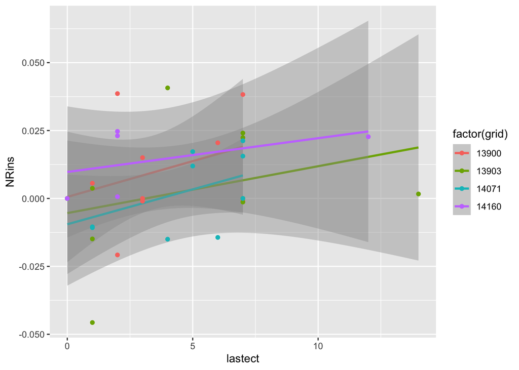

```r
ggplot(data=aparc, aes(x=lastect, y=NRins, colour=factor(grid)))+
  stat_smooth(method='lm')+
  geom_point()
```

## Establishing variable ect_frequency by calculating the frequency at which the last 3 ects were received before a given mri for each patient.

```r
test_2['ect_frequency'] <- 0
for (x in 1:nrow(test_2)){
  if (test_2$iper.redcap_event_name[x] == 'mri_arm_1' & test_2$iper.record_id[x] == 58){
    i <- test_2$iper.ect_completed_pre_mri[x]
    if (i < 3){
      test_2$ect_frequency[x] <- 0
    }
    else{
     j <- as.numeric(difftime(test_2$iper.date_mri[x], dates_1$iper.ect_date[i-2]))
     test_2$ect_frequency[x] <- 3/(j)
    }
  }
}

for (x in 1:nrow(test_2)){
  if (test_2$iper.redcap_event_name[x] == 'mri_arm_1' & test_2$iper.record_id[x] == 59){
    i <- test_2$iper.ect_completed_pre_mri[x]
    if (i < 3){
      test_2$ect_frequency[x] <- 0
    }
    else{
      j <- as.numeric(difftime(test_2$iper.date_mri[x], dates_2$iper.ect_date[i-2]))
      test_2$ect_frequency[x] <- 3/(j)
    }
  }
}

for (x in 1:nrow(test_2)){
  if (test_2$iper.redcap_event_name[x] == 'mri_arm_1' & test_2$iper.record_id[x] == 61){
    i <- test_2$iper.ect_completed_pre_mri[x]
    if (i < 3){
      test_2$ect_frequency[x] <- 0
    }
    else{
      j <- as.numeric(difftime(test_2$iper.date_mri[x], dates_3$iper.ect_date[i-2]))
      test_2$ect_frequency[x] <- 3/(j)
    }
  }
}

for (x in 1:nrow(test_2)){
  if (test_2$iper.redcap_event_name[x] == 'mri_arm_1' & test_2$iper.record_id[x] == 62){
    i <- test_2$iper.ect_completed_pre_mri[x]
    if (i < 3){
      test_2$ect_frequency[x] <- 0
    }
    else{
      j <- as.numeric(difftime(test_2$iper.date_mri[x], dates_4$iper.ect_date[i-2]))
      test_2$ect_frequency[x] <- 3/(j)
    }
  }
}

time_analysis <- select(filter(test_2, iper.redcap_event_name == 'mri_arm_1' ),c(iper.record_id, iper.gridnumber, iper.redcap_repeat_instance, last_ect, ect_frequency))

fvoldf <- cbind(fvoldf, ect$iper.ect_completed_pre_mri)
colnames(fvoldf)[which(colnames(fvoldf)=='ect$iper.ect_completed_pre_mri')] <- 'ect_pre_mri'

fvoldf <- cbind(fvoldf, time_analysis$ect_frequency)
colnames(fvoldf)[which(colnames(fvoldf)=='time_analysis$ect_frequency')] <- 'ect_frequency'

aparc <- cbind(aparc, time_analysis$ect_frequency)
colnames(aparc)[which(colnames(aparc)=='time_analysis$ect_frequency')] <- 'ect_frequency'
```

## Graphs for volumetric changes against ect_frequency

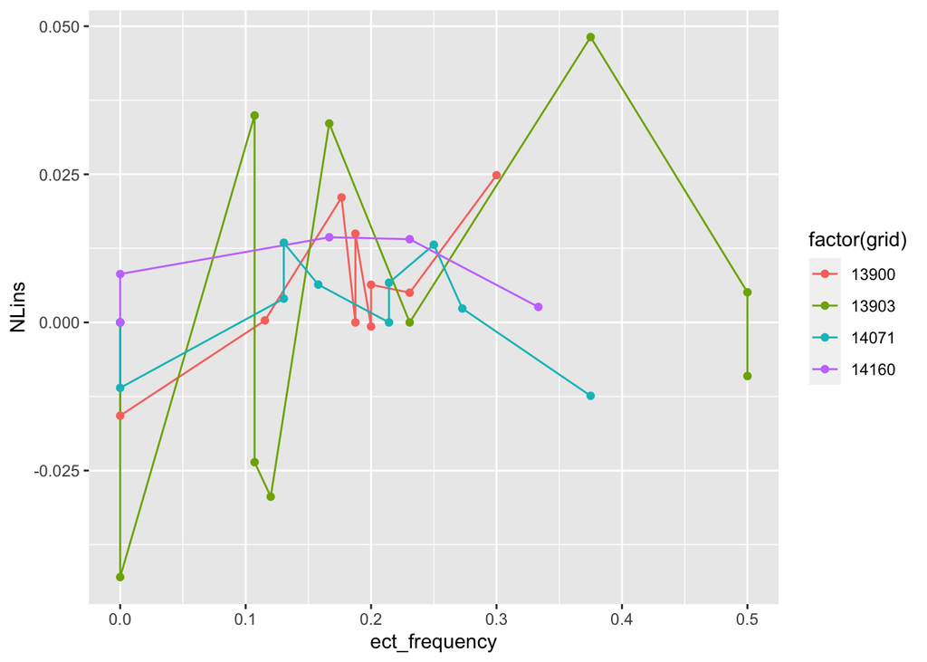

```r
#NLins
ggplot(data=aparc, aes(x=ect_frequency, y=NLins, colour=factor(grid)))+
  geom_line()+
  geom_point()
```

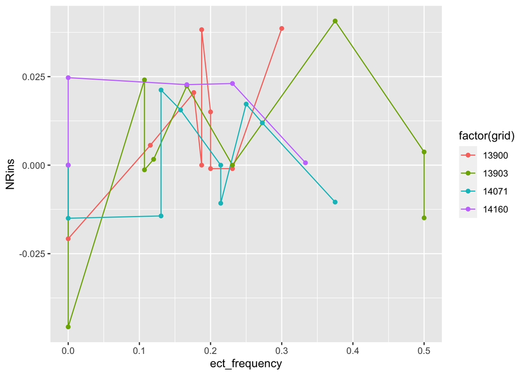

```r
#NRins
ggplot(data=aparc, aes(x=ect_frequency, y=NRins, colour=factor(grid)))+
  geom_line()+
  geom_point()
```

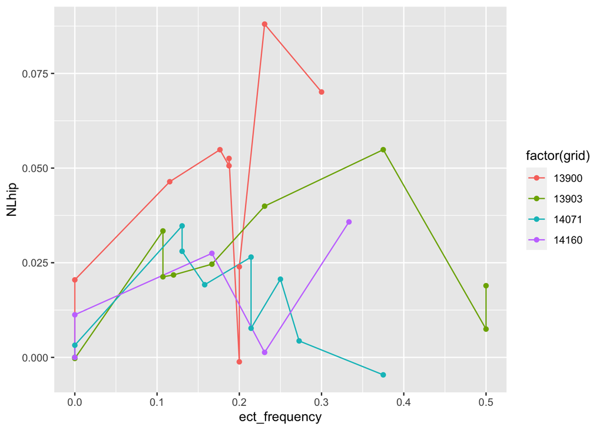

```r
#NLhip
ggplot(data=fvoldf, aes(x=ect_frequency, y=NLhip, colour=factor(grid)))+
  geom_line()+
  geom_point()
```

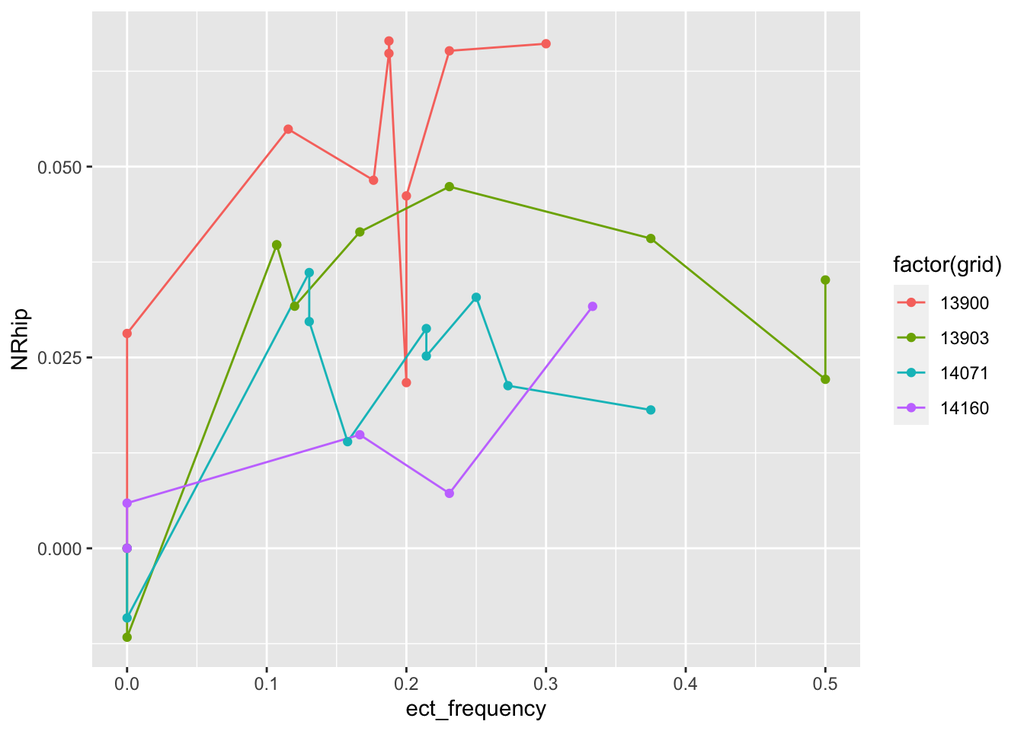

```r
#NRhip
ggplot(data=fvoldf, aes(x=ect_frequency, y=NRhip, colour=factor(grid)))+
  geom_line()+
  geom_point()
```

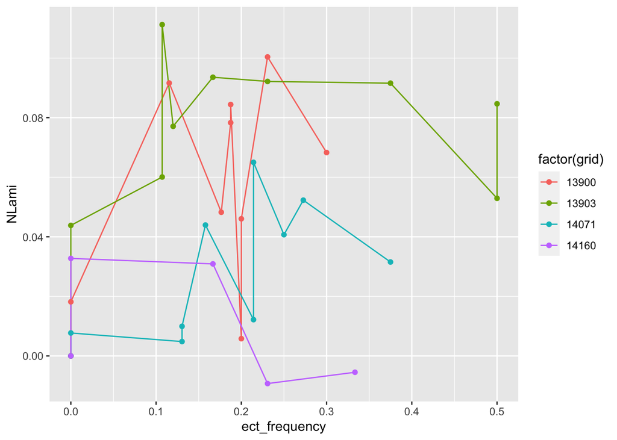

```r
#NLami
ggplot(data=fvoldf, aes(x=ect_frequency, y=NLami, colour=factor(grid)))+
  geom_line()+
  geom_point()
```

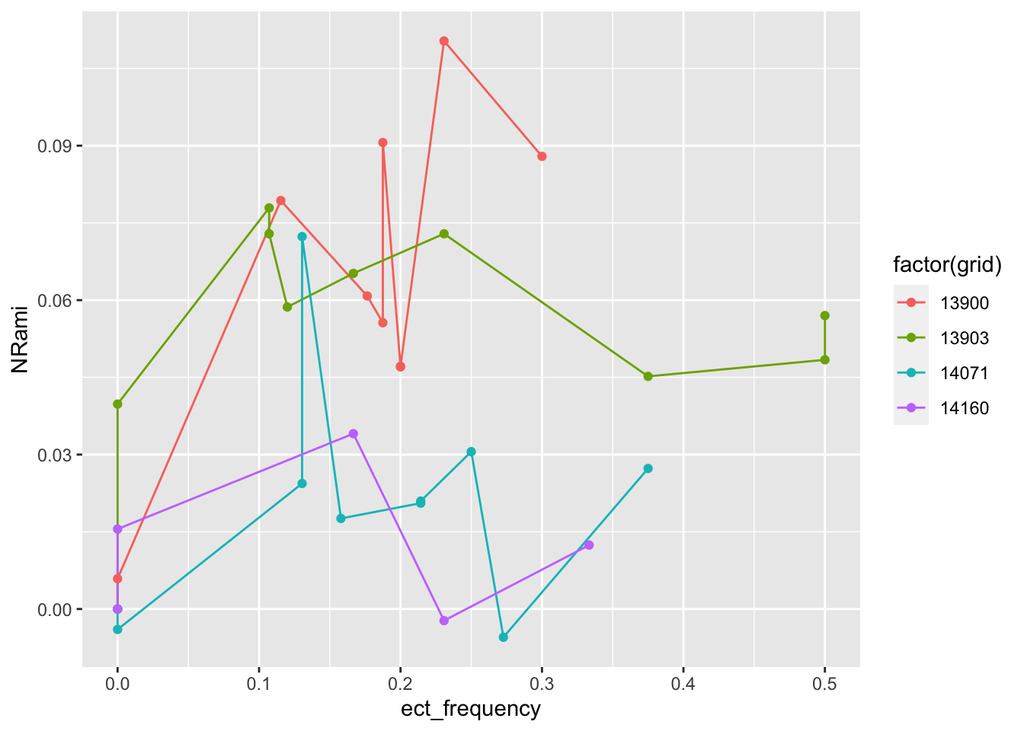

```r
#NRami
ggplot(data=fvoldf, aes(x=ect_frequency, y=NRami, colour=factor(grid)))+
  geom_line()+
  geom_point()
```

## Testing model to predict volumetric changes via total ect and ect frequency and their interaction

```r
#NRhip
summary(lm(NRhip ~ ect_frequency + ect_total + ect_total:ect_frequency, data = fvoldf))
```

```
##
## Call:
## lm(formula = NRhip ~ ect_frequency + ect_total + ect_total:ect_frequency,
##     data = fvoldf)
##
## Residuals:
##       Min        1Q    Median        3Q       Max
## -0.018864 -0.010056 -0.003571  0.008622  0.030429
##
## Coefficients:
##                           Estimate Std. Error t value Pr(>|t|)
## (Intercept)              5.423e-03  4.730e-03   1.146  0.26038
## ect_frequency            4.868e-02  2.611e-02   1.865  0.07170 .
## ect_total                1.274e-05  3.889e-06   3.277  0.00259 **
## ect_frequency:ect_total -1.616e-06  2.237e-05  -0.072  0.94289
## ---
## Signif. codes:  0 '***' 0.001 '**' 0.01 '*' 0.05 '.' 0.1 ' ' 1
##
## Residual standard error: 0.01397 on 31 degrees of freedom
## Multiple R-squared:  0.619,  Adjusted R-squared:  0.5822
## F-statistic: 16.79 on 3 and 31 DF,  p-value: 1.163e-06
```

```r
#NLhip
summary(lm(NLhip ~ ect_frequency + ect_total + ect_total:ect_frequency, data = fvoldf))
```

```
##
## Call:
## lm(formula = NLhip ~ ect_frequency + ect_total + ect_total:ect_frequency,
##     data = fvoldf)
##
## Residuals:
##       Min        1Q    Median        3Q       Max
## -0.028859 -0.010713 -0.005616  0.009728  0.044716
##
## Coefficients:
##                           Estimate Std. Error t value Pr(>|t|)
## (Intercept)              1.024e-02  6.071e-03   1.686    0.102
## ect_frequency           -1.110e-02  3.351e-02  -0.331    0.743
## ect_total                4.813e-06  4.992e-06   0.964    0.342
## ect_frequency:ect_total  4.256e-05  2.872e-05   1.482    0.148
##
## Residual standard error: 0.01793 on 31 degrees of freedom
## Multiple R-squared:  0.4222, Adjusted R-squared:  0.3663
## F-statistic: 7.552 on 3 and 31 DF,  p-value: 0.0006235
```

```r
#NRami
summary(lm(NRami ~ ect_frequency + ect_total + ect_total:ect_frequency, data = fvoldf))
```

```
##
## Call:
## lm(formula = NRami ~ ect_frequency + ect_total + ect_total:ect_frequency,
##     data = fvoldf)
##
## Residuals:
##       Min        1Q    Median        3Q       Max
## -0.029483 -0.009453 -0.004411  0.010187  0.041143
##
## Coefficients:
##                          Estimate Std. Error t value Pr(>|t|)
## (Intercept)             9.160e-03  5.912e-03   1.549 0.131416
## ect_frequency           1.614e-02  3.263e-02   0.495 0.624278
## ect_total               1.926e-05  4.861e-06   3.962 0.000405 ***
## ect_frequency:ect_total 2.030e-05  2.796e-05   0.726 0.473233
## ---
## Signif. codes:  0 '***' 0.001 '**' 0.01 '*' 0.05 '.' 0.1 ' ' 1
##
## Residual standard error: 0.01746 on 31 degrees of freedom
## Multiple R-squared:  0.7271, Adjusted R-squared:  0.7007
## F-statistic: 27.53 on 3 and 31 DF,  p-value: 7.116e-09
```

```r
#NRami
summary(lm(NLami ~ ect_frequency + ect_total + ect_total:ect_frequency, data = fvoldf))
```

```
##
## Call:
## lm(formula = NLami ~ ect_frequency + ect_total + ect_total:ect_frequency,
##     data = fvoldf)
##
## Residuals:
##       Min        1Q    Median        3Q       Max
## -0.031863 -0.010253 -0.000684  0.013372  0.034415
##
## Coefficients:
##                          Estimate Std. Error t value Pr(>|t|)
## (Intercept)             1.025e-02  6.178e-03   1.660  0.10709
## ect_frequency           8.576e-03  3.410e-02   0.251  0.80310
## ect_total               1.778e-05  5.080e-06   3.499  0.00144 **
## ect_frequency:ect_total 5.013e-05  2.922e-05   1.715  0.09626 .
## ---
## Signif. codes:  0 '***' 0.001 '**' 0.01 '*' 0.05 '.' 0.1 ' ' 1
##
## Residual standard error: 0.01825 on 31 degrees of freedom
## Multiple R-squared:  0.7688, Adjusted R-squared:  0.7465
## F-statistic: 34.37 on 3 and 31 DF,  p-value: 5.57e-10
```

```r
#NRins
summary(lm(NRins ~ ect_frequency + ect_total + ect_total:ect_frequency, data = aparc))
```

```
##
## Call:
## lm(formula = NRins ~ ect_frequency + ect_total + ect_total:ect_frequency,
##     data = aparc)
##
## Residuals:
##       Min        1Q    Median        3Q       Max
## -0.043675 -0.013380  0.002521  0.012945  0.026916
##
## Coefficients:
##                           Estimate Std. Error t value Pr(>|t|)
## (Intercept)             -2.521e-03  6.066e-03  -0.416    0.681
## ect_frequency            1.867e-02  3.348e-02   0.558    0.581
## ect_total                3.677e-06  4.988e-06   0.737    0.466
## ect_frequency:ect_total  3.984e-06  2.869e-05   0.139    0.890
##
## Residual standard error: 0.01791 on 31 degrees of freedom
## Multiple R-squared:  0.1187, Adjusted R-squared:  0.0334
## F-statistic: 1.392 on 3 and 31 DF,  p-value: 0.2638
```

```r
#NLins
summary(lm(NLins ~ ect_frequency + ect_total + ect_total:ect_frequency, data = aparc))
```

```
##
## Call:
## lm(formula = NLins ~ ect_frequency + ect_total + ect_total:ect_frequency,
##     data = aparc)
##
## Residuals:
##       Min        1Q    Median        3Q       Max
## -0.040365 -0.006422  0.002429  0.010654  0.031695
##
## Coefficients:
##                           Estimate Std. Error t value Pr(>|t|)
## (Intercept)             -2.429e-03  5.779e-03  -0.420    0.677
## ect_frequency            1.017e-02  3.190e-02   0.319    0.752
## ect_total               -1.373e-06  4.752e-06  -0.289    0.775
## ect_frequency:ect_total  2.565e-05  2.734e-05   0.938    0.355
##
## Residual standard error: 0.01707 on 31 degrees of freedom
## Multiple R-squared:  0.1267, Adjusted R-squared:  0.04216
## F-statistic: 1.499 on 3 and 31 DF,  p-value: 0.2342
```

### Testing exponential decay model for volumetric changes in the hippocampus

## organizing days past each ect from mri date

```r
for (x in 1:14){
  test_2[paste0('e-',x)] <- NA
}

for (x in 1:nrow(test_2)){
  i <- test_2$iper.ect_completed_pre_mri[x]
  if (test_2$iper.redcap_event_name[x] == 'mri_arm_1' & test_2$iper.record_id[x] == 58 & i > 0){
    for (j in 1:i){
    test_2[x, paste0('e-',j)] <- as.integer(difftime(test_2$iper.date_mri[x], dates_1$iper.ect_date[j]))
    }
  }
  else if (test_2$iper.redcap_event_name[x] == 'mri_arm_1' & test_2$iper.record_id[x] == 59 & i > 0){
    for (j in 1:i){
      test_2[x, paste0('e-',j)] <- as.integer(difftime(test_2$iper.date_mri[x], dates_2$iper.ect_date[j]))
    }
  }
  else if (test_2$iper.redcap_event_name[x] == 'mri_arm_1' & test_2$iper.record_id[x] == 61 & i > 0){
    for (j in 1:i){
      test_2[x, paste0('e-',j)] <- as.integer(difftime(test_2$iper.date_mri[x], dates_3$iper.ect_date[j]))
    }
  }
  else if (test_2$iper.redcap_event_name[x] == 'mri_arm_1' & test_2$iper.record_id[x] == 62 & i > 0){
    for (j in 1:i){
      test_2[x, paste0('e-',j)] <- as.integer(difftime(test_2$iper.date_mri[x], dates_4$iper.ect_date[j]))
    }
  }
}

time_analysis <- select(filter(test_2, iper.redcap_event_name == 'mri_arm_1' ),c(iper.record_id, iper.gridnumber, iper.redcap_repeat_instance, last_ect, ect_frequency, 'e-1', 'e-2', 'e-3', 'e-4', 'e-5', 'e-6', 'e-7', 'e-8', 'e-9', 'e-10', 'e-11', 'e-12', 'e-13', 'e-14'))
fvoldf <- cbind(fvoldf, time_analysis[c('e-1', 'e-2', 'e-3', 'e-4', 'e-5', 'e-6', 'e-7', 'e-8', 'e-9', 'e-10', 'e-11', 'e-12', 'e-13', 'e-14')])
```

## ect impact function used to find residuals for given exponential model

```r
ectimpact <-function(A, k, fvoldf, roi)
{
  fsum =0
  for (i in 1:dim(fvoldf)[1])
  {
    msum = 0
    if (fvoldf$ect_pre_mri[i]!=0)
    {
      for (j in 1:fvoldf$ect_pre_mri[i])
      {
        msum = msum + A*exp((-1)*k*fvoldf[i, paste0('e-',j)])
      }

    }
    fsum = fsum + (fvoldf[i,roi]-msum)*(fvoldf[i,roi]-msum)
  }
  return(fsum)
}
```

## function that generates list of estimates based on model

```r
fitcalc <-function(A, k, fvoldf, roi)
{
  fsum =c()
  for (i in 1:dim(fvoldf)[1])
  {
    msum = 0
    if (fvoldf$ect_pre_mri[i]!=0)
    {
      for (j in 1:fvoldf$ect_pre_mri[i])
      {
        msum = msum + A*exp((-1)*k*fvoldf[i, paste0('e-',j)])
      }

    }
    fsum = c(fsum, msum)
  }
  return(fsum)
}
```

## function that optimzes A and k values for exponential model for each patient (13900, 13903, 14071, 14160) for the right hippocampus volume changes

```r
#13900
funtoopt<-function(x){
  A<-x[1]
  k<-x[2]
  ectimpact(A,k,fvoldf[which(fvoldf$grid == 13900),], 'NRhip')
}
funtoopt(c(1,1))
```

```
## [1] 0.1277686
```

```r
myparam <- optim(c(1,1), funtoopt)

#13903
funtoopt2<-function(x)
{
  A<-x[1]
  k<-x[2]
  ectimpact(A,k,fvoldf[which(fvoldf$grid == 13903),], 'NRhip')
}
funtoopt2(c(1,1))
```

```
## [1] 0.4172317
```

```r
myparam2 <- optim(c(1,1), funtoopt2)

#14071
funtoopt3<-function(x)
{
  A<-x[1]
  k<-x[2]
  ectimpact(A,k,fvoldf[which(fvoldf$grid == 14071),], 'NRhip')
}
funtoopt3(c(1,1))
```

```
## [1] 0.2465983
```

```r
myparam3 <- optim(c(1,1), funtoopt3)

#14160
funtoopt4<-function(x)
{
  A<-x[1]
  k<-x[2]
  ectimpact(A,k,fvoldf[which(fvoldf$grid == 14160),], 'NRhip')
}
funtoopt4(c(1,1))
```

```
## [1] 0.04535645
```

```r
myparam4 <- optim(c(1,1), funtoopt4)
```

## Model Fit Graphs for right hippocampus for each patients

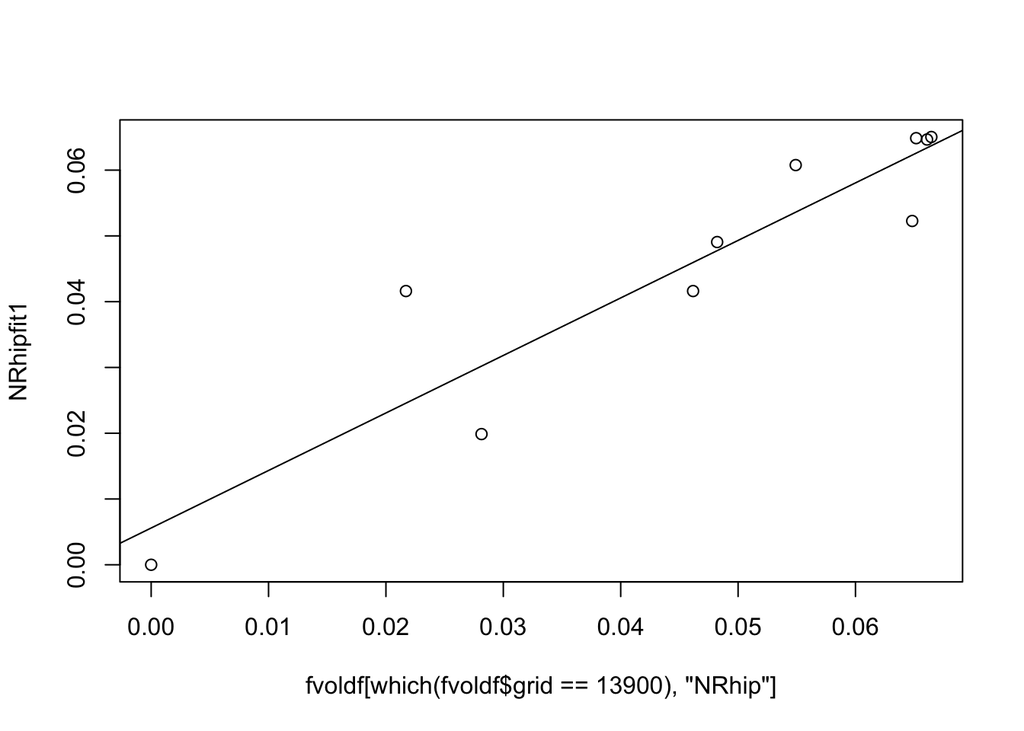

```r
#13900
NRhipfit1 <- fitcalc(myparam$par[1],myparam$par[2],fvoldf[which(fvoldf$grid == 13900),], 'NRhip')
plot(fvoldf[which(fvoldf$grid == 13900),'NRhip'], NRhipfit1)
abline(lm(NRhipfit1 ~ fvoldf[which(fvoldf$grid == 13900),'NRhip']))
```

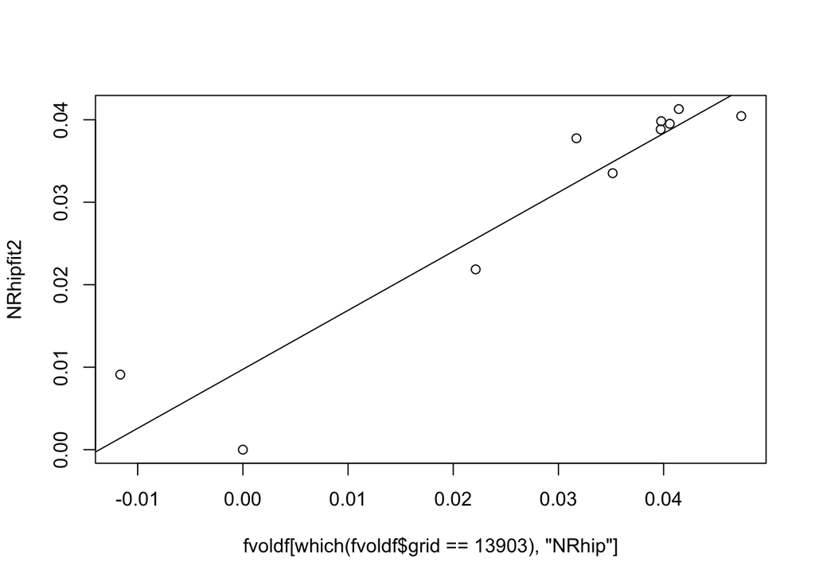

```r
#13903
NRhipfit2 <- fitcalc(myparam2$par[1],myparam2$par[2],fvoldf[which(fvoldf$grid == 13903),], 'NRhip')
plot(fvoldf[which(fvoldf$grid == 13903),'NRhip'], NRhipfit2)
abline(lm(NRhipfit2 ~ fvoldf[which(fvoldf$grid == 13903),'NRhip']))
```

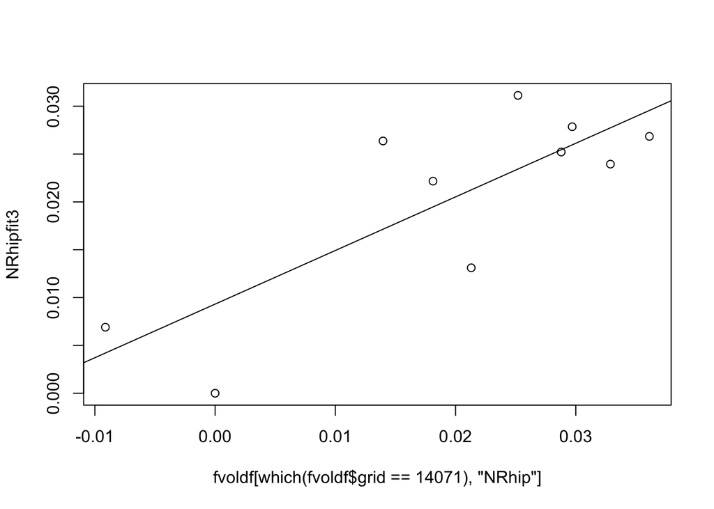

```r
#14071
NRhipfit3 <- fitcalc(myparam3$par[1],myparam3$par[2],fvoldf[which(fvoldf$grid == 14071),], 'NRhip')
plot(fvoldf[which(fvoldf$grid == 14071),'NRhip'], NRhipfit3)
abline(lm(NRhipfit3 ~ fvoldf[which(fvoldf$grid == 14071),'NRhip']))
```

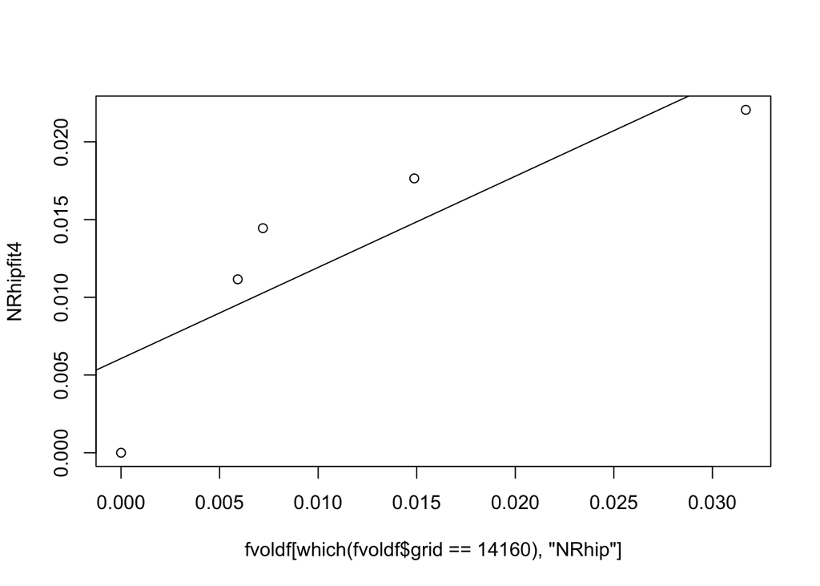

```r
#14160
NRhipfit4 <- fitcalc(myparam4$par[1],myparam4$par[2],fvoldf[which(fvoldf$grid == 14160),], 'NRhip')
plot(fvoldf[which(fvoldf$grid == 14160),'NRhip'], NRhipfit4)
abline(lm(NRhipfit4 ~ fvoldf[which(fvoldf$grid == 14160),'NRhip']))
```